# Question

The equation below has one extraneous solution and one valid solution.

$$-5+2\sqrt{4x+16}~=~-2x-7$$

We can find both using [Desmos](https://www.desmos.com/calculator). To find the valid solution, find the intersection of the following two curves:

$$f(x)=-5+2\sqrt{4x+16}$$
$$L(x)=-2x-7$$

You should see half a parabola facing sideways and a line. Click where the two curves cross. The $x$ value is the valid solution.

The extraneous solution also has a geometric interpretation! We need to complete the parabola by plotting the following curve:

$$g(x)=-5-2\sqrt{4x+16}$$

You should see the line crosses this second half of the parabola. Click on the intersection. The $x$ value is the extraneous solution.

- Valid: ##ANSWER1##
- Extraneous: ##ANSWER2##

## Answerlist

- -10
- -9
- -8
- -7
- -6
- -5
- -4
- -3
- -2
- -1
- 0
- 1
- 2
- 3
- 4
- 5
- 6
- 7
- 8
- 9
- 10
- -10
- -9
- -8
- -7
- -6
- -5
- -4
- -3
- -2
- -1
- 0
- 1
- 2
- 3
- 4
- 5
- 6
- 7
- 8
- 9
- 10

# Solution

The valid solution is $x=-3$, and the extraneous solution is $x=5$. Your Desmos graph should look somewhat similar to the graph below:

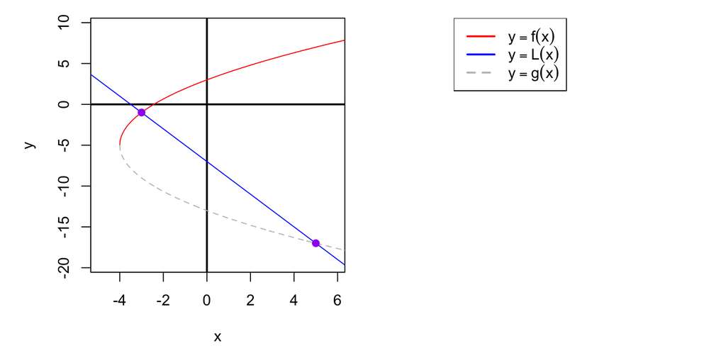

# Meta-information

extype: cloze exclozetype: schoice|schoice exsolution: 000000010000000000000|000000000000000100000 exname: zzz